# Godaddy Microbusiness Forecasting

Mohammad Solki

2023-02-28

```r
# Set the working directory
setwd("/Users/dreamer/Downloads/Godaddy/godaddy_microbusiness_forecasting")
```

```r
# Importing the libraries
library(tidyverse)
```

```r
# ggplot2, purrr, tibble, dplyr, tidyr, stringr, readr, forcats
library(mice)
library(maps)
#library(ggplot2)
library(gridExtra)
#library(dplyr)
library(caret)
library(gbm)
#library(png)
#library(ggmap)
library(viridis)
library(mapdata)

# Code starts here
```

### Exploring the datasets

Explore the datasets to get a better understanding of the data.  
Load the train and test datasets into dataframes.

```r
# Load train.csv into a dataframe
train_df <- read.csv("./datasets/train.csv")

# Load test.csv into a dataframe
test_df <- read.csv("./datasets/test.csv")

# Load census_starter.csv into a dataframe
census_df <- read.csv("./datasets/census_starter.csv")
```

Check the dataframes

```r
# Display the first 10 rows of the dataframes
head(train_df, n = 10)
```

```
##             row_id cfips         county   state first_day_of_month
## 1  1001_2019-08-01  1001 Autauga County Alabama         2019-08-01
## 2  1001_2019-09-01  1001 Autauga County Alabama         2019-09-01
## 3  1001_2019-10-01  1001 Autauga County Alabama         2019-10-01
## 4  1001_2019-11-01  1001 Autauga County Alabama         2019-11-01
## 5  1001_2019-12-01  1001 Autauga County Alabama         2019-12-01
## 6  1001_2020-01-01  1001 Autauga County Alabama         2020-01-01
## 7  1001_2020-02-01  1001 Autauga County Alabama         2020-02-01
## 8  1001_2020-03-01  1001 Autauga County Alabama         2020-03-01
## 9  1001_2020-04-01  1001 Autauga County Alabama         2020-04-01
## 10 1001_2020-05-01  1001 Autauga County Alabama         2020-05-01
##    microbusiness_density active
## 1               3.007682   1249
## 2               2.884870   1198
## 3               3.055843   1269
## 4               2.993233   1243
## 5               2.993233   1243
## 6               2.969090   1242
## 7               2.909326   1217
## 8               2.933231   1227
## 9               3.000167   1255
## 10              3.004948   1257
```

```r
head(test_df, n = 10)
```

```
##             row_id cfips first_day_of_month
## 1  1001_2022-11-01  1001         2022-11-01
## 2  1003_2022-11-01  1003         2022-11-01
## 3  1005_2022-11-01  1005         2022-11-01
## 4  1007_2022-11-01  1007         2022-11-01
## 5  1009_2022-11-01  1009         2022-11-01
## 6  1011_2022-11-01  1011         2022-11-01
## 7  1013_2022-11-01  1013         2022-11-01
## 8  1015_2022-11-01  1015         2022-11-01
## 9  1017_2022-11-01  1017         2022-11-01
## 10 1019_2022-11-01  1019         2022-11-01
```

```r
head(census_df, n = 10)
```

```
##    pct_bb_2017 pct_bb_2018 pct_bb_2019 pct_bb_2020 pct_bb_2021 cfips
## 1         76.6        78.9        80.6        82.7        85.5  1001
## 2         74.5        78.1        81.8        85.1        87.9  1003
## 3         57.2        60.4        60.5        64.6        64.6  1005
## 4         62.0        66.1        69.2        76.1        74.6  1007
## 5         65.8        68.5        73.0        79.6        81.0  1009
## 6         49.4        58.9        60.1        60.6        59.4  1011
## 7         58.2        62.1        64.6        73.6        76.3  1013
## 8         71.0        73.0        75.1        79.8        81.6  1015
## 9         62.8        66.5        69.4        74.5        77.1  1017
## 10        67.5        68.6        70.7        75.0        76.7  1019
##    pct_college_2017 pct_college_2018 pct_college_2019 pct_college_2020
## 1              14.5             15.9             16.1             16.7
## 2              20.4             20.7             21.0             20.2
## 3               7.6              7.8              7.6              7.3
```

[output cut: 62 more lines]

```r
# Display the last 10 rows of the dataframes
tail(train_df, n = 10)
```

```
##                  row_id cfips        county   state first_day_of_month
## 122256 56045_2022-01-01 56045 Weston County Wyoming         2022-01-01
## 122257 56045_2022-02-01 56045 Weston County Wyoming         2022-02-01
## 122258 56045_2022-03-01 56045 Weston County Wyoming         2022-03-01
## 122259 56045_2022-04-01 56045 Weston County Wyoming         2022-04-01
## 122260 56045_2022-05-01 56045 Weston County Wyoming         2022-05-01
## 122261 56045_2022-06-01 56045 Weston County Wyoming         2022-06-01
## 122262 56045_2022-07-01 56045 Weston County Wyoming         2022-07-01
## 122263 56045_2022-08-01 56045 Weston County Wyoming         2022-08-01
## 122264 56045_2022-09-01 56045 Weston County Wyoming         2022-09-01
## 122265 56045_2022-10-01 56045 Weston County Wyoming         2022-10-01
##        microbusiness_density active
## 122256              1.749688     98
## 122257              1.749688     98
## 122258              1.767542     99
## 122259              1.767542     99
## 122260              1.803249    101
## 122261              1.803249    101
## 122262              1.803249    101
## 122263              1.785395    100
## 122264              1.785395    100
## 122265              1.785395    100
```

```r
tail(test_df, n = 10)
```

```
##                 row_id cfips first_day_of_month
## 25071 56027_2023-06-01 56027         2023-06-01
## 25072 56029_2023-06-01 56029         2023-06-01
## 25073 56031_2023-06-01 56031         2023-06-01
## 25074 56033_2023-06-01 56033         2023-06-01
## 25075 56035_2023-06-01 56035         2023-06-01
## 25076 56037_2023-06-01 56037         2023-06-01
## 25077 56039_2023-06-01 56039         2023-06-01
## 25078 56041_2023-06-01 56041         2023-06-01
## 25079 56043_2023-06-01 56043         2023-06-01
## 25080 56045_2023-06-01 56045         2023-06-01
```

```r
tail(census_df, n = 10)
```

```
##      pct_bb_2017 pct_bb_2018 pct_bb_2019 pct_bb_2020 pct_bb_2021 cfips
## 3133        67.8        73.3        72.2        77.6        74.3 56027
## 3134        80.4        82.2        85.7        86.7        87.9 56029
## 3135        68.4        69.2        70.9        74.5        75.1 56031
## 3136        80.9        81.1        82.9        82.8        84.7 56033
## 3137        82.9        81.7        85.6        88.1        89.8 56035
## 3138        82.2        82.4        84.0        86.7        88.4 56037
## 3139        83.5        85.9        87.1        89.1        90.5 56039
## 3140        83.8        88.2        89.5        91.4        90.6 56041
## 3141        76.4        78.3        78.2        82.8        85.4 56043
## 3142        71.1        73.3        76.8        79.7        81.3 56045
##      pct_college_2017 pct_college_2018 pct_college_2019 pct_college_2020
## 3133             14.2             13.0             14.5             14.7
## 3134             19.2             19.1             21.5             21.8
## 3135             14.6             14.1             10.9             10.8
```

[output cut: 73 more lines]

```r
# Display information about the train dataframe
str(train_df)
```

```
## 'data.frame':    122265 obs. of  7 variables:
##  $ row_id               : chr  "1001_2019-08-01" "1001_2019-09-01" "1001_2019-10-01" "1001_2019-11-01" ...
##  $ cfips                : int  1001 1001 1001 1001 1001 1001 1001 1001 1001 1001 ...
##  $ county               : chr  "Autauga County" "Autauga County" "Autauga County" "Autauga County" ...
##  $ state                : chr  "Alabama" "Alabama" "Alabama" "Alabama" ...
##  $ first_day_of_month   : chr  "2019-08-01" "2019-09-01" "2019-10-01" "2019-11-01" ...
##  $ microbusiness_density: num  3.01 2.88 3.06 2.99 2.99 ...
##  $ active               : int  1249 1198 1269 1243 1243 1242 1217 1227 1255 1257 ...
```

```r
cat(rep("=", 40), "\n") # Print a line of 40 equal signs
summary(train_df)
```

```
##     row_id              cfips          county             state
##  Length:122265      Min.   : 1001   Length:122265      Length:122265
##  Class :character   1st Qu.:18177   Class :character   Class :character
##  Mode  :character   Median :29173   Mode  :character   Mode  :character
##                     Mean   :30376
##                     3rd Qu.:45077
##                     Max.   :56045
##  first_day_of_month microbusiness_density     active
##  Length:122265      Min.   :  0.000       Min.   :      0
##  Class :character   1st Qu.:  1.639       1st Qu.:    145
##  Mode  :character   Median :  2.587       Median :    488
##                     Mean   :  3.818       Mean   :   6443
##                     3rd Qu.:  4.519       3rd Qu.:   2124
##                     Max.   :284.340       Max.   :1167744
```

```r
# Display information about the test dataframe
str(test_df)
```

```
## 'data.frame':    25080 obs. of  3 variables:
##  $ row_id            : chr  "1001_2022-11-01" "1003_2022-11-01" "1005_2022-11-01" "1007_2022-11-01" ...
##  $ cfips             : int  1001 1003 1005 1007 1009 1011 1013 1015 1017 1019 ...
##  $ first_day_of_month: chr  "2022-11-01" "2022-11-01" "2022-11-01" "2022-11-01" ...
```

```r
cat(rep("=", 40), "\n") # Print a line of 40 equal signs
summary(test_df)
```

```
##     row_id              cfips       first_day_of_month
##  Length:25080       Min.   : 1001   Length:25080
##  Class :character   1st Qu.:18177   Class :character
##  Mode  :character   Median :29173   Mode  :character
##                     Mean   :30376
##                     3rd Qu.:45077
##                     Max.   :56045
```

```r
# Display information about the census dataframe
str(census_df)
```

```
## 'data.frame':    3142 obs. of  26 variables:
##  $ pct_bb_2017          : num  76.6 74.5 57.2 62 65.8 49.4 58.2 71 62.8 67.5 ...
##  $ pct_bb_2018          : num  78.9 78.1 60.4 66.1 68.5 58.9 62.1 73 66.5 68.6 ...
##  $ pct_bb_2019          : num  80.6 81.8 60.5 69.2 73 60.1 64.6 75.1 69.4 70.7 ...
##  $ pct_bb_2020          : num  82.7 85.1 64.6 76.1 79.6 60.6 73.6 79.8 74.5 75 ...
##  $ pct_bb_2021          : num  85.5 87.9 64.6 74.6 81 59.4 76.3 81.6 77.1 76.7 ...
##  $ cfips                : int  1001 1003 1005 1007 1009 1011 1013 1015 1017 1019 ...
##  $ pct_college_2017     : num  14.5 20.4 7.6 8.1 8.7 6.6 9.6 10.2 9 6.6 ...
##  $ pct_college_2018     : num  15.9 20.7 7.8 7.6 8.1 7.4 9.7 10.2 9.3 6.8 ...
##  $ pct_college_2019     : num  16.1 21 7.6 6.5 8.6 7.4 9.7 10.5 9.5 6.6 ...
##  $ pct_college_2020     : num  16.7 20.2 7.3 7.4 8.9 6.1 10.1 10.5 10.5 6.3 ...
##  $ pct_college_2021     : num  16.4 20.6 6.7 7.9 9.3 8.1 8.1 11.4 9.6 6.2 ...
##  $ pct_foreign_born_2017: num  2.1 3.2 2.7 1 4.5 1.8 1 2.6 1.3 0.7 ...
##  $ pct_foreign_born_2018: num  2 3.4 2.5 1.4 4.4 0.9 1.4 2.7 1.4 0.8 ...
##  $ pct_foreign_born_2019: num  2.3 3.7 2.7 1.5 4.5 0.7 0.8 2.7 1.8 0.9 ...
##  $ pct_foreign_born_2020: num  2.3 3.4 2.6 1.6 4.4 1.5 1.9 2.5 1.9 1.9 ...
##  $ pct_foreign_born_2021: num  2.1 3.5 2.6 1.1 4.5 1.2 1.7 2.5 2 2 ...
##  $ pct_it_workers_2017  : num  1.3 1.4 0.5 1.2 1.3 0.4 1.1 1.4 2.4 1.4 ...
##  $ pct_it_workers_2018  : num  1.1 1.3 0.3 1.4 1.4 0.3 1.4 1.4 2.1 1.3 ...
##  $ pct_it_workers_2019  : num  0.7 1.4 0.8 1.6 0.9 0.5 1.7 1.2 2.1 1.2 ...
##  $ pct_it_workers_2020  : num  0.6 1 1.1 1.7 1.1 0.3 1.3 1 2.3 0.9 ...
##  $ pct_it_workers_2021  : num  1.1 1.3 0.8 2.1 0.9 0.2 1.4 1 1.8 0.4 ...
##  $ median_hh_inc_2017   : int  55317 52562 33368 43404 47412 29655 36326 43686 37342 40041 ...
##  $ median_hh_inc_2018   : num  58786 55962 34186 45340 48695 ...
##  $ median_hh_inc_2019   : int  58731 58320 32525 47542 49358 37785 40688 47255 42289 41919 ...
##  $ median_hh_inc_2020   : num  57982 61756 34990 51721 48922 ...
##  $ median_hh_inc_2021   : num  62660 64346 36422 54277 52830 ...
```

```r
cat(rep("=", 40), "\n") # Print a line of 40 equal signs
summary(census_df)
```

```
##   pct_bb_2017     pct_bb_2018     pct_bb_2019     pct_bb_2020
##  Min.   :24.50   Min.   :25.70   Min.   :34.80   Min.   :33.30
##  1st Qu.:64.20   1st Qu.:67.42   1st Qu.:70.50   1st Qu.:74.10
##  Median :70.70   Median :73.60   Median :76.45   Median :79.60
##  Mean   :69.92   Mean   :72.69   Mean   :75.40   Mean   :78.54
##  3rd Qu.:76.40   3rd Qu.:78.80   3rd Qu.:81.40   3rd Qu.:84.10
##  Max.   :94.60   Max.   :95.50   Max.   :96.00   Max.   :97.10
##                                                  NA's   :1
##   pct_bb_2021        cfips       pct_college_2017 pct_college_2018
##  Min.   :37.00   Min.   : 1001   Min.   : 2.40    Min.   : 0.00
##  1st Qu.:76.40   1st Qu.:18178   1st Qu.: 9.70    1st Qu.: 9.90
##  Median :81.70   Median :29176   Median :12.80    Median :13.00
##  Mean   :80.54   Mean   :30384   Mean   :13.81    Mean   :14.01
##  3rd Qu.:85.90   3rd Qu.:45080   3rd Qu.:16.80    3rd Qu.:17.10
##  Max.   :97.60   Max.   :56045   Max.   :43.70    Max.   :48.00
##  NA's   :1
##  pct_college_2019 pct_college_2020 pct_college_2021 pct_foreign_born_2017
##  Min.   : 0.00    Min.   : 0.00    Min.   : 0.00    Min.   : 0.000
##  1st Qu.:10.10    1st Qu.:10.50    1st Qu.:10.60    1st Qu.: 1.400
##  Median :13.25    Median :13.60    Median :13.80    Median : 2.700
##  Mean   :14.24    Mean   :14.63    Mean   :14.85    Mean   : 4.702
##  3rd Qu.:17.30    3rd Qu.:17.90    3rd Qu.:18.00    3rd Qu.: 5.700
##  Max.   :45.40    Max.   :43.00    Max.   :43.70    Max.   :52.900
##                   NA's   :1        NA's   :1
##  pct_foreign_born_2018 pct_foreign_born_2019 pct_foreign_born_2020
##  Min.   : 0.000        Min.   : 0.000        Min.   : 0.000
##  1st Qu.: 1.400        1st Qu.: 1.400        1st Qu.: 1.400
##  Median : 2.700        Median : 2.700        Median : 2.800
##  Mean   : 4.725        Mean   : 4.769        Mean   : 4.749
##  3rd Qu.: 5.700        3rd Qu.: 5.700        3rd Qu.: 5.700
##  Max.   :53.300        Max.   :53.700        Max.   :54.000
##                                              NA's   :1
##  pct_foreign_born_2021 pct_it_workers_2017 pct_it_workers_2018
##  Min.   : 0.000        Min.   : 0.000      Min.   : 0.000
##  1st Qu.: 1.400        1st Qu.: 0.800      1st Qu.: 0.800
##  Median : 2.700        Median : 1.300      Median : 1.300
##  Mean   : 4.744        Mean   : 1.427      Mean   : 1.382
##  3rd Qu.: 5.700        3rd Qu.: 1.900      3rd Qu.: 1.800
##  Max.   :54.000        Max.   :17.400      Max.   :11.700
##  NA's   :1                                 NA's   :1
##  pct_it_workers_2019 pct_it_workers_2020 pct_it_workers_2021 median_hh_inc_2017
##  Min.   : 0.000      Min.   : 0.000      Min.   : 0.000      Min.   : 19264
##  1st Qu.: 0.700      1st Qu.: 0.700      1st Qu.: 0.600      1st Qu.: 41123
##  Median : 1.200      Median : 1.200      Median : 1.100      Median : 48066
##  Mean   : 1.339      Mean   : 1.309      Mean   : 1.273      Mean   : 49754
##  3rd Qu.: 1.800      3rd Qu.: 1.800      3rd Qu.: 1.700      3rd Qu.: 55764
##  Max.   :10.500      Max.   :15.200      Max.   :15.200      Max.   :129588
##                      NA's   :1           NA's   :1
##  median_hh_inc_2018 median_hh_inc_2019 median_hh_inc_2020 median_hh_inc_2021
##  Min.   : 20188     Min.   : 21504     Min.   : 22292     Min.   : 17109
##  1st Qu.: 42480     1st Qu.: 44155     1st Qu.: 45653     1st Qu.: 48180
##  Median : 49888     Median : 51758     Median : 52842     Median : 55907
##  Mean   : 51583     Mean   : 53476     Mean   : 55012     Mean   : 58223
##  3rd Qu.: 57611     3rd Qu.: 59867     3rd Qu.: 61501     3rd Qu.: 64930
##  Max.   :136268     Max.   :142299     Max.   :147111     Max.   :156821
##  NA's   :1                             NA's   :2          NA's   :2
```

The is.na() function is used to create a logical matrix where TRUE represents a missing value and FALSE represents a non-missing value. The colSums() function is then used to count the number of missing values in each column of the data frame. If the sum of a column is greater than 0, it means that there is at least one missing value in that column.

```r
# Check for missing values in the train data frame
colSums(is.na(train_df))
```

```
##                row_id                 cfips                county
##                     0                     0                     0
##                 state    first_day_of_month microbusiness_density
##                     0                     0                     0
##                active
##                     0
```

```r
# Check for missing values in the test data frame
colSums(is.na(test_df))
```

```
##             row_id              cfips first_day_of_month
##                  0                  0                  0
```

```r
# Check for missing values in the census data frame
colSums(is.na(census_df))
```

```
##           pct_bb_2017           pct_bb_2018           pct_bb_2019
##                     0                     0                     0
##           pct_bb_2020           pct_bb_2021                 cfips
##                     1                     1                     0
##      pct_college_2017      pct_college_2018      pct_college_2019
##                     0                     0                     0
##      pct_college_2020      pct_college_2021 pct_foreign_born_2017
##                     1                     1                     0
## pct_foreign_born_2018 pct_foreign_born_2019 pct_foreign_born_2020
##                     0                     0                     1
## pct_foreign_born_2021   pct_it_workers_2017   pct_it_workers_2018
##                     1                     0                     1
##   pct_it_workers_2019   pct_it_workers_2020   pct_it_workers_2021
##                     0                     1                     1
##    median_hh_inc_2017    median_hh_inc_2018    median_hh_inc_2019
##                     0                     1                     0
##    median_hh_inc_2020    median_hh_inc_2021
##                     2                     2
```

We use the complete.cases() function to determine which rows have complete data and which rows have missing values. The complete.cases() function returns a logical vector indicating which rows have no missing values. Therefore, to identify the rows with missing values, we use the ! operator to negate the logical vector returned by complete.cases(). Then, we use the is.na() function to identify which columns have missing values for each missing row:

```r
# Identify rows with missing values in census_df
missing_rows <- which(!complete.cases(census_df))
```

```r
# Identify columns with missing values for each missing row
for (i in missing_rows) {
  cat("Row", i, "has missing values in columns:",
      paste(names(census_df)[is.na(census_df[i,])], collapse = ", "), "\n")
}
```

```
## Row 93 has missing values in columns: pct_bb_2020, pct_bb_2021, pct_college_2020, pct_college_2021, pct_foreign_born_2020, pct_foreign_born_2021, pct_it_workers_2020, pct_it_workers_2021, median_hh_inc_2020, median_hh_inc_2021
## Row 1817 has missing values in columns: pct_it_workers_2018, median_hh_inc_2018
## Row 2645 has missing values in columns: median_hh_inc_2020
## Row 2674 has missing values in columns: median_hh_inc_2021
```

```r
print(census_df[missing_rows,])
```

```
##      pct_bb_2017 pct_bb_2018 pct_bb_2019 pct_bb_2020 pct_bb_2021 cfips
## 93          80.5        79.1        80.4          NA          NA  2261
## 1817        49.1        52.1        57.6        60.7        63.5 35039
## 2645        66.3        66.6        61.2        63.2        70.1 48243
## 2674        64.5        72.7        73.3        96.8        97.0 48301
##      pct_college_2017 pct_college_2018 pct_college_2019 pct_college_2020
## 93               23.1             19.0             16.5               NA
## 1817             12.0             12.5             12.6             10.6
## 2645             18.4             16.0             10.8             14.3
## 2674              4.7              0.0              0.0              0.0
##      pct_college_2021 pct_foreign_born_2017 pct_foreign_born_2018
## 93                 NA                   4.9                   6.3
## 1817             10.1                   4.5                   3.7
## 2645             10.9                  22.4                  14.9
## 2674              0.0                  10.8                  15.7
```

[output cut: 25 more lines]

We use the mice package to impute missing values in the census_df dataframe.

m: the number of imputations to generate was set to 5, because, generally, m should be set to at least 5 for good imputation performance. creating too many datasets will increase the computational cost and may not necessarily lead to better results.

maxit: maxit was set to 50 to allow for a larger number of iterations to ensure that the imputation algorithm converges and fills in missing values as accurately as possible.

method: In this case, we are using “pmm” which stands for “Predictive Mean Matching”, because it is a flexible and widely used imputation method that works well with continuous variables. The method estimates the missing values by drawing from a set of observed values that have similar characteristics to the missing values.

```r
# Impute missing data using mice
imputed_df <- mice(census_df, m = 5, maxit = 50, method = "pmm")
# Extract imputed data
imputed_data <- complete(imputed_df)

# Check for missing values in imputed data
colSums(is.na(imputed_data))
```

```
##           pct_bb_2017           pct_bb_2018           pct_bb_2019
##                     0                     0                     0
##           pct_bb_2020           pct_bb_2021                 cfips
##                     0                     0                     0
##      pct_college_2017      pct_college_2018      pct_college_2019
##                     0                     0                     0
##      pct_college_2020      pct_college_2021 pct_foreign_born_2017
##                     0                     0                     0
## pct_foreign_born_2018 pct_foreign_born_2019 pct_foreign_born_2020
##                     0                     0                     0
## pct_foreign_born_2021   pct_it_workers_2017   pct_it_workers_2018
##                     0                     0                     0
##   pct_it_workers_2019   pct_it_workers_2020   pct_it_workers_2021
##                     0                     0                     0
##    median_hh_inc_2017    median_hh_inc_2018    median_hh_inc_2019
##                     0                     0                     0
##    median_hh_inc_2020    median_hh_inc_2021
##                     0                     0
```

```r
print(imputed_data[missing_rows,])
```

```
##      pct_bb_2017 pct_bb_2018 pct_bb_2019 pct_bb_2020 pct_bb_2021 cfips
## 93          80.5        79.1        80.4        80.5        82.8  2261
## 1817        49.1        52.1        57.6        60.7        63.5 35039
## 2645        66.3        66.6        61.2        63.2        70.1 48243
## 2674        64.5        72.7        73.3        96.8        97.0 48301
##      pct_college_2017 pct_college_2018 pct_college_2019 pct_college_2020
## 93               23.1             19.0             16.5             17.2
## 1817             12.0             12.5             12.6             10.6
## 2645             18.4             16.0             10.8             14.3
## 2674              4.7              0.0              0.0              0.0
##      pct_college_2021 pct_foreign_born_2017 pct_foreign_born_2018
## 93               20.0                   4.9                   6.3
## 1817             10.1                   4.5                   3.7
## 2645             10.9                  22.4                  14.9
## 2674              0.0                  10.8                  15.7
```

[output cut: 25 more lines]

```r
index <- unique(train_df$first_day_of_month)
print(index)
```

```
##  [1] "2019-08-01" "2019-09-01" "2019-10-01" "2019-11-01" "2019-12-01"
##  [6] "2020-01-01" "2020-02-01" "2020-03-01" "2020-04-01" "2020-05-01"
## [11] "2020-06-01" "2020-07-01" "2020-08-01" "2020-09-01" "2020-10-01"
## [16] "2020-11-01" "2020-12-01" "2021-01-01" "2021-02-01" "2021-03-01"
## [21] "2021-04-01" "2021-05-01" "2021-06-01" "2021-07-01" "2021-08-01"
## [26] "2021-09-01" "2021-10-01" "2021-11-01" "2021-12-01" "2022-01-01"
## [31] "2022-02-01" "2022-03-01" "2022-04-01" "2022-05-01" "2022-06-01"
## [36] "2022-07-01" "2022-08-01" "2022-09-01" "2022-10-01"
```

training data is from 08/2019 to 10/2022

```r
index <- unique(test_df$first_day_of_month)
print(index)
```

```
## [1] "2022-11-01" "2022-12-01" "2023-01-01" "2023-02-01" "2023-03-01"
## [6] "2023-04-01" "2023-05-01" "2023-06-01"
```

prediction dates are from 11/2022 to 06/2023

## EDA

```r
# Add year, month and year_month columns to train_df
train_df$year <- as.integer(substr(train_df$first_day_of_month, 1, 4))
train_df$month <- as.integer(substr(train_df$first_day_of_month, 6, 7))
train_df$year_month <- substr(train_df$first_day_of_month, 1, 7)

# Add year, month and year_month columns to test_df
test_df$year <- as.integer(substr(test_df$first_day_of_month, 1, 4))
test_df$month <- as.integer(substr(test_df$first_day_of_month, 6, 7))
test_df$year_month <- substr(test_df$first_day_of_month, 1, 7)
```

```r
str(train_df)
```

```
## 'data.frame':    122265 obs. of  10 variables:
##  $ row_id               : chr  "1001_2019-08-01" "1001_2019-09-01" "1001_2019-10-01" "1001_2019-11-01" ...
##  $ cfips                : int  1001 1001 1001 1001 1001 1001 1001 1001 1001 1001 ...
##  $ county               : chr  "Autauga County" "Autauga County" "Autauga County" "Autauga County" ...
##  $ state                : chr  "Alabama" "Alabama" "Alabama" "Alabama" ...
##  $ first_day_of_month   : chr  "2019-08-01" "2019-09-01" "2019-10-01" "2019-11-01" ...
##  $ microbusiness_density: num  3.01 2.88 3.06 2.99 2.99 ...
##  $ active               : int  1249 1198 1269 1243 1243 1242 1217 1227 1255 1257 ...
##  $ year                 : int  2019 2019 2019 2019 2019 2020 2020 2020 2020 2020 ...
##  $ month                : int  8 9 10 11 12 1 2 3 4 5 ...
##  $ year_month           : chr  "2019-08" "2019-09" "2019-10" "2019-11" ...
```

```r
cat(rep("=", 40), "\n")
str(test_df)
```

```
## 'data.frame':    25080 obs. of  6 variables:
##  $ row_id            : chr  "1001_2022-11-01" "1003_2022-11-01" "1005_2022-11-01" "1007_2022-11-01" ...
##  $ cfips             : int  1001 1003 1005 1007 1009 1011 1013 1015 1017 1019 ...
##  $ first_day_of_month: chr  "2022-11-01" "2022-11-01" "2022-11-01" "2022-11-01" ...
##  $ year              : int  2022 2022 2022 2022 2022 2022 2022 2022 2022 2022 ...
##  $ month             : int  11 11 11 11 11 11 11 11 11 11 ...
##  $ year_month        : chr  "2022-11" "2022-11" "2022-11" "2022-11" ...
```

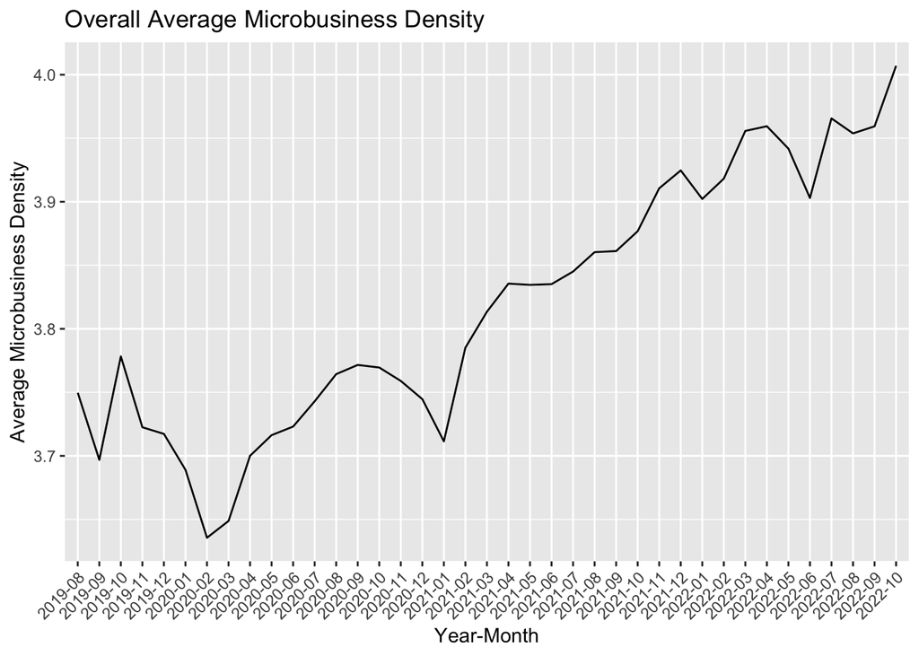

```r
# Group train_df by year_month and calculate the mean value of microbusiness_density for each group
train_df_mean <- train_df %>%
  group_by(year_month) %>%
  summarise(mean_microbusiness_density = mean(microbusiness_density))

# Create plot
ggplot(train_df_mean, aes(x = year_month, y = mean_microbusiness_density, group = 1)) +
  geom_line() +
  labs(title = "Overall Average Microbusiness Density",
       x = "Year-Month",
       y = "Average Microbusiness Density") +
  theme(axis.text.x = element_text(angle = 45, hjust = 1))
```

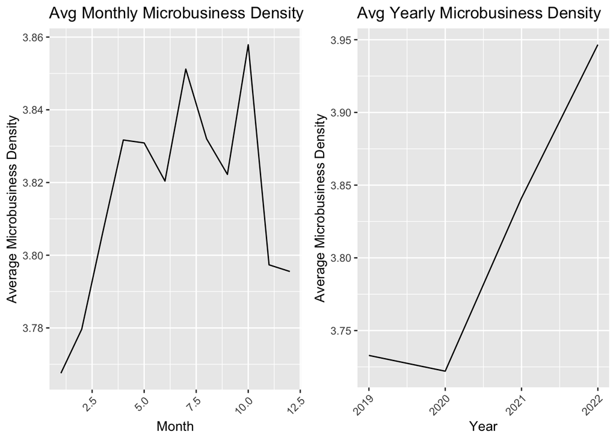

```r
# Group train_df by year and calculate the mean value of microbusiness_density for each group
train_df_mean_year <- train_df %>%
  group_by(year) %>%
  summarize(avg_microbusiness_density = mean(microbusiness_density))

# Group train_df by month and calculate the mean value of the target variable for each group
train_df_mean_month <- train_df %>%
  group_by(month) %>%
  summarize(avg_microbusiness_density = mean(microbusiness_density))

# Plot the monthly mean values
p1 <-
  ggplot(train_df_mean_month, aes(x = month, y = avg_microbusiness_density)) +
  geom_line() +
  ggtitle("Avg Monthly Microbusiness Density") +
  xlab("Month") +
  ylab("Average Microbusiness Density") +
  theme(axis.text.x = element_text(angle = 45, hjust = 1))

# Plot the yearly mean values
p2 <-
  ggplot(train_df_mean_year, aes(x = year, y = avg_microbusiness_density)) +
  geom_line() +
  ggtitle("Avg Yearly Microbusiness Density") +
  xlab("Year") +
  ylab("Average Microbusiness Density") +
  theme(axis.text.x = element_text(angle = 45, hjust = 1))

# Display the plots side by side
grid.arrange(p1, p2, ncol=2)
```

The Bureau of Economic Analysis (BEA) divides the United States into eight distinct economic regions. These regions are based on similarities in economic characteristics such as industry composition, income levels, and employment patterns. The eight regions are:

1. New England: Connecticut, Maine, Massachusetts, New Hampshire, Rhode Island, and Vermont.

   The economy in this region is largely based on manufacturing, healthcare, education, and finance.
2. Mideast: Delaware, Maryland, New Jersey, New York, Pennsylvania, and the District of Columbia.

   The region has a diverse economy, with a mix of manufacturing, finance, healthcare, and professional services.
3. Great Lakes: Illinois, Indiana, Michigan, Ohio, and Wisconsin.

   The region has a strong manufacturing base, particularly in the automotive industry, and also has a significant healthcare sector.
4. Plains: Iowa, Kansas, Minnesota, Missouri, Nebraska, North Dakota, and South Dakota.

   Agriculture and energy production are major industries in this region, along with manufacturing and healthcare.
5. Southeast: Alabama, Arkansas, Florida, Georgia, Kentucky, Louisiana, Mississippi, North Carolina, South Carolina, Tennessee, Virginia, and West Virginia.

   The Southeast has a diverse economy, with significant industries in healthcare, finance, and manufacturing, as well as tourism and agriculture.
6. Southwest: Arizona, New Mexico, Oklahoma, and Texas.

   The region has a strong energy sector, particularly in oil and gas production, and also has significant industries in manufacturing, healthcare, and finance.
7. Rocky Mountain: Colorado, Idaho, Montana, Utah, and Wyoming.

   The region is known for its natural resources, particularly in mining and energy production, as well as tourism, healthcare, and manufacturing.
8. Far West: Alaska, California, Hawaii, Nevada, Oregon, and Washington.

   This region has a diverse economy, with significant industries in technology, finance, healthcare, and manufacturing, as well as tourism and agriculture.

[figure not shown]

```r
# Get the map of the United States
us_map <- map_data("county")
usa_map <- map_data("state")

# Create a lookup table for state abbreviations and their corresponding full names
state_names <- data.frame(state = state.abb, name = tolower(state.name))

# Map the regions to the states
region_map <- usa_map %>%
#left_join(state_names, by = c("region" = "state")) %>%
  left_join(state_names, by = c("region" = "name")) %>%
# merge(usa_map, state_names, by.x=c("region"), by.y=c("name")) %>%
  mutate(region =
           ifelse(region %in% c("connecticut", "maine", "massachusetts", "new hampshire", "rhode island", "vermont"), "New England",
                         ifelse(region %in% c("delaware", "maryland", "new jersey", "new york", "pennsylvania", "district of columbia"), "Mideast",
                                ifelse(region %in% c("illinois", "indiana", "michigan", "ohio", "wisconsin"), "Great Lakes",
                                       ifelse(region %in% c("iowa", "kansas", "minnesota", "missouri", "nebraska", "north dakota", "south dakota"), "Plains",
                                              ifelse(region %in% c("alabama", "arkansas", "florida", "georgia", "kentucky", "louisiana", "mississippi", "north carolina", "south carolina", "tennessee", "virginia", "west virginia"), "Southeast",
                                                     ifelse(region %in% c("arizona", "new mexico", "oklahoma", "texas"), "Southwest",
                                                            ifelse(region %in% c("colorado", "idaho", "montana", "utah", "wyoming"), "Rocky Mountain",
                                                                   ifelse(region %in% c("alaska", "california", "hawaii", "nevada", "oregon", "washington"), "Far West", NA
                                                                          )
                                                                   )
                                                            )
                                                     )
                                              )
                                       )
                                )
                         )
         )

# Summarize the data to get the center coordinates of each state
#state_centers <- region_map %>%
#  group_by(state) %>%
#  summarise(long = mean(long), lat = mean(lat))
# add labels
states <- aggregate(cbind(long, lat) ~ region, data=us_map,
                FUN=function(x)mean(range(x)))
states$group <- c("AL", "AR", "AZ", "CA", "CO", "CT", "DE", "DC", "FL", "GA", "IA",
              "ID", "IL", "IN", "KS", "KY", "LA", "MA", "MD", "ME", "MI", "MN",
              "MO", "MS", "MT", "NC", "ND", "NE", "NH", "NJ", "NM", "NV", "NY",
              "OH", "OK", "OR", "PA", "RI", "SC", "SD", "TN", "TX", "UT", "VA",
              "VT", "WA", "WI", "WV", "WY")

# names(states)[names(states) == "region"] <- "group"


#Plot the map
ggplot(region_map, aes(x = long, y = lat, group = group, fill = region)) +
  geom_polygon(color = "black", show.legend = FALSE) +
#  geom_text(aes(label = state), data = region_map, size = 3, vjust = 2, hjust = 2) +
#  geom_text(aes(label = state), data = state_centers, size = 2, vjust = 2, hjust = 2) +
  geom_text(data = states, aes(long, lat, label = group), size = 2.5, inherit.aes = FALSE, color = "white", fontface = "bold") +
#  scale_fill_gradient(low = "white", high = "darkred") +
#  scale_fill_manual(values = viridis(n = 60), na.value = "gray") +
  labs(title = "Bureau of Economic Analysis Regional Divisions Map", fill = "Region") +
#  geom_text(aes(x = long, y = lat, label = state), data = state_centers, size = 3, color = "white") +
  theme_void() +
  theme(panel.background = element_rect(fill = "gray75", color = NA))
```

```r
str(states)
```

```
## 'data.frame':    49 obs. of  4 variables:
##  $ region: chr  "alabama" "arizona" "arkansas" "california" ...
##  $ long  : num  -86.7 -111.9 -92.1 -119.3 -105.6 ...
##  $ lat   : num  32.6 34.2 34.8 37.3 39 ...
##  $ group : chr  "AL" "AR" "AZ" "CA" ...
```

First, we need to convert state and county columns in `train_df` to lowercase letters. Because, the data from map_data() will be in lowercase and when merging two dataframes it might cause problems.

```r
# Convert state and county columns in train_df to lowercase
train_df <- train_df %>%
  mutate(state = tolower(state)) %>%
  mutate(county = tolower(county))
```

Then, we’ll create a new column named region and assign region values based on state column:

```r
# Create a new column named region and initialize all values as NA
train_df$region <- NA

# Assign region values based on state column
for (i in 1:nrow(train_df)) {
  if (train_df$state[i] %in% c("connecticut", "maine", "massachusetts", "new hampshire", "rhode island", "vermont")) {
    train_df$region[i] <- "new england"
  } else if (train_df$state[i] %in% c("delaware", "maryland", "new jersey", "new york", "pennsylvania", "district of columbia")) {
    train_df$region[i] <- "mideast"
  } else if (train_df$state[i] %in% c("illinois", "indiana", "michigan", "ohio", "wisconsin")) {
    train_df$region[i] <- "great lakes"
  } else if (train_df$state[i] %in% c("iowa", "kansas", "minnesota", "missouri", "nebraska", "north dakota", "south dakota")) {
    train_df$region[i] <- "plains"
  } else if (train_df$state[i] %in% c("alabama", "arkansas", "florida", "georgia", "kentucky", "louisiana", "mississippi", "north carolina", "south carolina", "tennessee", "virginia", "west virginia")) {
    train_df$region[i] <- "southeast"
  } else if (train_df$state[i] %in% c("arizona", "new mexico", "oklahoma", "texas")) {
    train_df$region[i] <- "southwest"
  } else if (train_df$state[i] %in% c("colorado", "idaho", "montana", "utah", "wyoming")) {
    train_df$region[i] <- "rocky mountain"
  } else if (train_df$state[i] %in% c("alaska", "california", "hawaii", "nevada", "oregon", "washington")) {
    train_df$region[i] <- "far west"
  } else {
    train_df$region[i] <- "other"
  }
}
```

```r
# Print all the unique values in the region column
unique(train_df$region)
```

```
## [1] "southeast"      "far west"       "southwest"      "rocky mountain"
## [5] "new england"    "mideast"        "great lakes"    "plains"
```

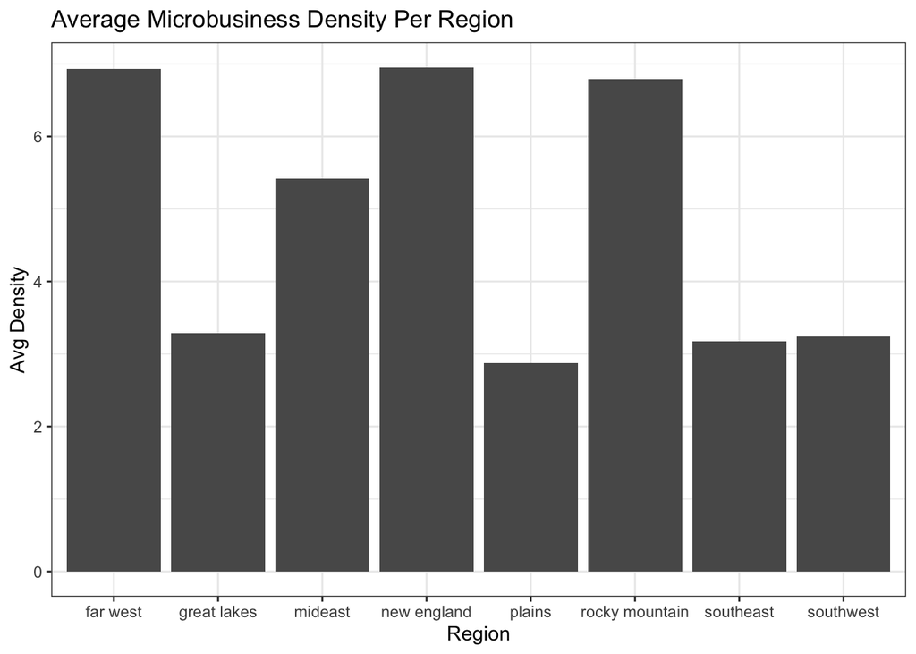

```r
# Group train_df by region and calculate average microbusiness density
train_df %>%
  group_by(region) %>%
  summarize(avg_density = mean(microbusiness_density)) %>%

  # Create bar plot of average density by region
  ggplot(aes(x = region, y = avg_density)) +
  geom_bar(stat = "identity") +

  # Add plot title and axis labels
  labs(title = "Average Microbusiness Density Per Region",
       x = "Region", y = "Avg Density") +

  # Apply a black and white theme to the plot
  theme_bw()
```

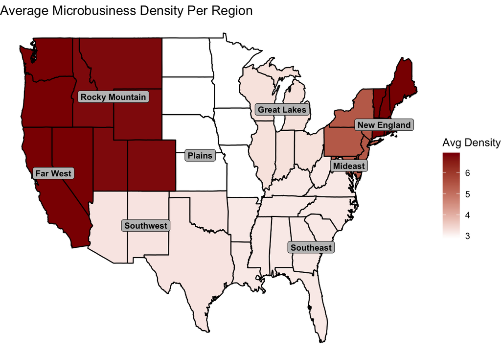

```r
# Group train_df by region and calculate average microbusiness density
avg_density <- train_df %>%
  group_by(region) %>%
  summarize(avg_density = mean(microbusiness_density))

# Create a lookup table for state abbreviations and their corresponding full names
state_names <- data.frame(state = state.abb, name = tolower(state.name))

# Lowercase region column of region_map
region_map <- region_map %>%
  mutate(region = tolower(region))

# Merge the average density data with the region_map data
plot_data <- merge(region_map, avg_density, by = "region") %>%
  arrange(order)

# Coordinates of the center of regions
bea_regions <- data.frame(
  group = c("New England", "Mideast", "Great Lakes", "Plains",
             "Southeast", "Southwest", "Rocky Mountain", "Far West"),
  x = c(-71.8, -76.9, -86.6, -98.5, -82.4, -106.4, -111.1, -119.8),
  y = c(42.2, 39, 43.4, 39.8, 32.6, 34.3, 44.4, 38.4)
)

# Create the plot
ggplot(plot_data, aes(x = long, y = lat, group = group, fill = avg_density)) +
  geom_polygon(color = "black") +
  geom_label(data = bea_regions,
             aes(x = x, y = y, label = group),
             size = 3, fontface = "bold",
             label.padding = unit(0.2, "lines"),
             label.size = 0.2,
             fill = "gray75", color = "black") +
  scale_fill_gradient(low = "white", high = "darkred") +
  # scale_fill_viridis(name = "Avg Density", na.value = "gray") +
  labs(title = "Average Microbusiness Density Per Region", fill = "Avg Density") +
  theme_void()
```

```r
str(train_df)
```

```
## 'data.frame':    122265 obs. of  11 variables:
##  $ row_id               : chr  "1001_2019-08-01" "1001_2019-09-01" "1001_2019-10-01" "1001_2019-11-01" ...
##  $ cfips                : int  1001 1001 1001 1001 1001 1001 1001 1001 1001 1001 ...
##  $ county               : chr  "autauga county" "autauga county" "autauga county" "autauga county" ...
##  $ state                : chr  "alabama" "alabama" "alabama" "alabama" ...
##  $ first_day_of_month   : chr  "2019-08-01" "2019-09-01" "2019-10-01" "2019-11-01" ...
##  $ microbusiness_density: num  3.01 2.88 3.06 2.99 2.99 ...
##  $ active               : int  1249 1198 1269 1243 1243 1242 1217 1227 1255 1257 ...
##  $ year                 : int  2019 2019 2019 2019 2019 2020 2020 2020 2020 2020 ...
##  $ month                : int  8 9 10 11 12 1 2 3 4 5 ...
##  $ year_month           : chr  "2019-08" "2019-09" "2019-10" "2019-11" ...
##  $ region               : chr  "southeast" "southeast" "southeast" "southeast" ...
```

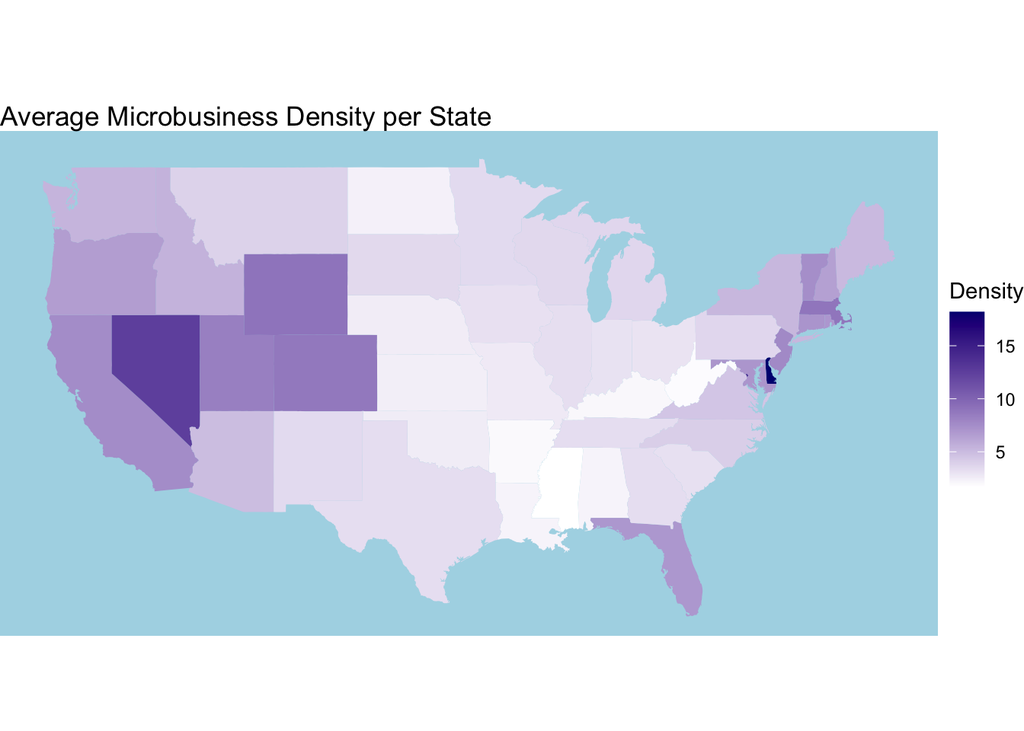

```r
# Aggregate microbusiness density by state
state_avg <- aggregate(microbusiness_density ~ state, data = train_df, FUN = mean)

# Load US map data
us_map <- map_data("state")

# Merge state_avg with us_map based on region and state
map_data <- merge(us_map, state_avg, by.x = "region", by.y = "state")

# Create a heatmap of microbusiness density by state
ggplot(map_data, aes(x = long, y = lat, group = group, fill = microbusiness_density)) +
  geom_polygon() +
  scale_fill_gradient(low = "white", high = "navyblue") +
  coord_map() +
  labs(title = "Average Microbusiness Density per State", fill = "Density") +
  theme_void() +
  theme(panel.background = element_rect(fill = "lightblue", color = NA))
```

[figure not shown]

```r
# Aggregate microbusiness density by county
county_avg <- aggregate(microbusiness_density ~ county, data = train_df, FUN = mean)

# Load US county map data
us_map <- map_data("county")

# Merge county_avg with us_map based on region and county
map_data <- merge(us_map, county_avg, by.x = c("subregion"), by.y = c("county"))

# Create a heatmap of microbusiness density by county using ggplot2
ggplot(map_data, aes(x = long, y = lat, group = group, fill = microbusiness_density)) +
  geom_polygon() +
  scale_fill_gradient(low = "white", high = "navyblue") +
  coord_map() +
  labs(title = "Average Microbusiness Density per County", fill = "Density") +
  theme_void() +
  theme(panel.background = element_rect(fill = "lightblue", color = NA))
```

[figure not shown]

```r
us.map <-  map_data('state')

# add PADD zones
us.map$PADD[us.map$region %in%
          c("maine", "vermont", "new hampshire", "massachusetts", "connecticut", "rhode island",
            "new york", "pennsylvania", "new jersey", "delaware", "district of columbia", "maryland",
            "west virginia", "virginia", "north carolina", "south carolina", "georgia", "florida")] <- "PADD 1: East Coast"
us.map$PADD[us.map$region %in%
          c("south dakota", "north dakota","nebraska", "kansas", "oklahoma",
            "minnesota", "iowa", "missouri", "wisconsin", "illinois", "indiana",
            "michigan", "ohio", "kentucky", "tennessee")] <- "PADD 2: Midwest"
us.map$PADD[us.map$region %in%
          c("new mexico", "texas", "arkansas", "louisiana", "alabama", "mississippi")] <- "PADD 3: Gulf Coast"
us.map$PADD[us.map$region %in%
          c("montana", "idaho", "wyoming", "utah", "colorado")] <- "PADD 4: Rocky Mountain"
us.map$PADD[us.map$region %in%
          c("washington", "oregon", "nevada", "arizona", "california")] <- "PADD 5: West Coast"

# subset the dataframe by padd zones and move lat/lon accordingly
us.map$lat.transp[us.map$PADD == "PADD 1: East Coast"] <- us.map$lat[us.map$PADD == "PADD 1: East Coast"]
us.map$long.transp[us.map$PADD == "PADD 1: East Coast"] <- us.map$long[us.map$PADD == "PADD 1: East Coast"] + 5

us.map$lat.transp[us.map$PADD == "PADD 2: Midwest"] <- us.map$lat[us.map$PADD == "PADD 2: Midwest"]
us.map$long.transp[us.map$PADD == "PADD 2: Midwest"] <- us.map$long[us.map$PADD == "PADD 2: Midwest"]

us.map$lat.transp[us.map$PADD == "PADD 3: Gulf Coast"] <- us.map$lat[us.map$PADD == "PADD 3: Gulf Coast"] - 3
us.map$long.transp[us.map$PADD == "PADD 3: Gulf Coast"] <- us.map$long[us.map$PADD == "PADD 3: Gulf Coast"]

us.map$lat.transp[us.map$PADD == "PADD 4: Rocky Mountain"] <- us.map$lat[us.map$PADD == "PADD 4: Rocky Mountain"]
us.map$long.transp[us.map$PADD == "PADD 4: Rocky Mountain"] <- us.map$long[us.map$PADD == "PADD 4: Rocky Mountain"] - 5

us.map$lat.transp[us.map$PADD == "PADD 5: West Coast"] <- us.map$lat[us.map$PADD == "PADD 5: West Coast"] - 2
us.map$long.transp[us.map$PADD == "PADD 5: West Coast"] <- us.map$long[us.map$PADD == "PADD 5: West Coast"] - 10

# add labels
states <- aggregate(cbind(long.transp, lat.transp) ~ region, data=us.map,
                FUN=function(x)mean(range(x)))
states$labels <- c("AL", "AR", "AZ", "CA", "CO", "CT", "DE", "DC", "FL", "GA", "IA",
              "ID", "IL", "IN", "KS", "KY", "LA", "MA", "MD", "ME", "MI", "MN",
              "MO", "MS", "MT", "NC", "ND", "NE", "NH", "NJ", "NM", "NV", "NY",
              "OH", "OK", "OR", "PA", "RI", "SC", "SD", "TN", "TX", "UT", "VA",
              "VT", "WA", "WI", "WV", "WY")



# plot and use padd zone as fill
ggplot(us.map,  aes(x=long.transp, y=lat.transp), colour="white") +
  geom_polygon(aes(group = group, fill=PADD)) +
  geom_text(data=states, aes(long.transp, lat.transp, label=labels), size=3) +
  theme(panel.background = element_blank(),  # remove background
    panel.grid = element_blank(),
    axis.line = element_blank(),
    axis.title = element_blank(),
    axis.ticks = element_blank(),
    axis.text = element_blank()) +
  coord_equal()
```

```r
# Create a new column named "subregion" and initialize all values as NA
us_map$subregion <- NA

# Assign subregion values based on region column
for (i in 1:nrow(us_map)) {
  if (us_map$region[i] %in% c("connecticut", "maine", "massachusetts", "new hampshire", "rhode island", "vermont")) {
    us_map$subregion[i] <- "new england"
  } else if (us_map$region[i] %in% c("delaware", "maryland", "new jersey", "new york", "pennsylvania", "district of columbia")) {
    us_map$subregion[i] <- "mideast"
  } else if (us_map$region[i] %in% c("illinois", "indiana", "michigan", "ohio", "wisconsin")) {
    us_map$subregion[i] <- "great lakes"
  } else if (us_map$region[i] %in% c("iowa", "kansas", "minnesota", "missouri", "nebraska", "north dakota", "south dakota")) {
    us_map$subregion[i] <- "plains"
  } else if (us_map$region[i] %in% c("alabama", "arkansas", "florida", "georgia", "kentucky", "louisiana", "mississippi", "north carolina", "south carolina", "tennessee", "virginia", "west virginia")) {
    us_map$subregion[i] <- "southeast"
  } else if (us_map$region[i] %in% c("arizona", "new mexico", "oklahoma", "texas")) {
    us_map$subregion[i] <- "southwest"
  } else if (us_map$region[i] %in% c("colorado", "idaho", "montana", "utah", "wyoming")) {
    us_map$subregion[i] <- "rocky Mountain"
  } else if (us_map$region[i] %in% c("alaska", "california", "hawaii", "nevada", "oregon", "washington")) {
    us_map$subregion[i] <- "far west"
  } else {
    us_map$subregion[i] <- "other"
  }
}
```